```python
import matplotlib.patches as mpatches
import numpy as np
import pandas as pd
import seaborn as sns
from matplotlib import pyplot as plt
from datetime import timedelta
plt.style.use('seaborn')
%matplotlib inline
from sklearn import preprocessing
from sklearn.preprocessing import StandardScaler

## Remove warning label that would be shown with some graphs.
## Some libraries do not like some operations, but the operations yields correct results
import warnings
warnings.simplefilter(action='ignore', category=FutureWarning)
```

# *Portfolio 1*

# Analysis of Cycling Data

## Loading Data

The first dataset is an export of my ride data from [Strava](https://strava.com/), an online social network site for cycling and other sports. This data is a log of every ride since the start of 2018 and contains summary data like the distance and average speed. It was exported using the script `stravaget.py` which uses the stravalib module to read data. Some details of the fields exported by that script can be seen in [the documentation for stravalib](https://pythonhosted.org/stravalib/api.html#stravalib.model.Activity).

The exported data is a CSV file so that's easy to read, however the date information in the file is recorded in a different timezone (UTC) so we need to do a bit of conversion. In reading the data I'm setting the index of the data frame to be the datetime of the ride.

```python
strava = pd.read_csv('data/strava_export.csv', index_col='date', parse_dates=True)
strava.index = strava.index.tz_convert('UTC')
strava.head()
```

| date | average_heartrate | average_temp | average_watts | device_watts | distance | elapsed_time | elevation_gain | kudos | moving_time | workout_type |
| --- | --- | --- | --- | --- | --- | --- | --- | --- | --- | --- |
| 2018-01-02 20:47:51+00:00 | 100.6 | 21.0 | 73.8 | False | 15.2 | 94 | 316.00 m | 10 | 73 | Ride |
| 2018-01-04 01:36:53+00:00 | NaN | 24.0 | 131.7 | False | 18.0 | 52 | 236.00 m | 5 | 46 | Ride |
| 2018-01-04 02:56:00+00:00 | 83.1 | 25.0 | 13.8 | False | 0.0 | 3 | 0.00 m | 2 | 2 | Ride |
| 2018-01-04 05:37:04+00:00 | 110.1 | 24.0 | 113.6 | False | 22.9 | 77 | 246.00 m | 8 | 64 | Ride |
| 2018-01-05 19:22:46+00:00 | 110.9 | 20.0 | 147.7 | True | 58.4 | 189 | 676.00 m | 12 | 144 | Ride |

The second dataset comes from an application called [GoldenCheetah](https://www.goldencheetah.org/) which provides some analytics services over ride data. This has some of the same fields but adds a lot of analysis of the power, speed and heart rate data in each ride. This data overlaps with the Strava data but doesn't include all of the same rides.

Again we create an index using the datetime for each ride, this time combining two columns in the data (date and time) and localising to Sydney so that the times match those for the Strava data.

```python
cheetah = pd.read_csv('data/cheetah.csv', skipinitialspace=True)
cheetah.index = pd.to_datetime(cheetah['date'] + ' ' + cheetah['time'])
cheetah.index = cheetah.index.tz_localize('Australia/Sydney')
cheetah.head()
```

|  | date | time | filename | axPower | aPower Relative Intensity | aBikeScore | Skiba aVI | aPower Response Index | aIsoPower | aIF | ... | Rest AVNN | Rest SDNN | Rest rMSSD | Rest PNN50 | Rest LF | Rest HF | HRV Recovery Points | NP | IF | TSS |
| --- | --- | --- | --- | --- | --- | --- | --- | --- | --- | --- | --- | --- | --- | --- | --- | --- | --- | --- | --- | --- | --- |
| 2018-01-28 06:39:49+11:00 | 01/28/18 | 06:39:49 | 2018_01_28_06_39_49.json | 202.211 | 0.75452 | 16.6520 | 1.31920 | 1.67755 | 223.621 | 0.83441 | ... | 0 | 0 | 0 | 0 | 0 | 0 | 0 | 222.856 | 0.83155 | 20.2257 |
| 2018-01-28 07:01:32+11:00 | 01/28/18 | 07:01:32 | 2018_01_28_07_01_32.json | 226.039 | 0.84343 | 80.2669 | 1.21137 | 1.54250 | 246.185 | 0.91860 | ... | 0 | 0 | 0 | 0 | 0 | 0 | 0 | 245.365 | 0.91554 | 94.5787 |
| 2018-02-01 08:13:34+11:00 | 02/01/18 | 08:13:34 | 2018_02_01_08_13_34.json | 0.000 | 0.00000 | 0.0000 | 0.00000 | 0.00000 | 0.000 | 0.00000 | ... | 0 | 0 | 0 | 0 | 0 | 0 | 0 | 0.000 | 0.00000 | 0.0000 |
| 2018-02-06 08:06:42+11:00 | 02/06/18 | 08:06:42 | 2018_02_06_08_06_42.json | 221.672 | 0.82714 | 78.8866 | 1.35775 | 1.86002 | 254.409 | 0.94929 | ... | 0 | 0 | 0 | 0 | 0 | 0 | 0 | 253.702 | 0.94665 | 98.3269 |
| 2018-02-07 17:59:05+11:00 | 02/07/18 | 17:59:05 | 2018_02_07_17_59_05.json | 218.211 | 0.81422 | 159.4590 | 1.47188 | 1.74658 | 233.780 | 0.87231 | ... | 0 | 0 | 0 | 0 | 0 | 0 | 0 | 232.644 | 0.86808 | 171.0780 |

5 rows × 362 columns

The GoldenCheetah data contains many many variables (columns) and I won't go into all of them here. Some that are of particular interest for the analysis below are:

Here are definitions of some of the more important fields in the data. Capitalised fields come from the GoldenCheetah data while lowercase_fields come from Strava. There are many cases where fields are duplicated and in this case the values should be the same, although there is room for variation as the algorithm used to calculate them could be different in each case.

- Duration - overall duration of the ride, should be same as elapsed_time
- Time Moving - time spent moving (not resting or waiting at lights), should be the same as moving_time
- Elevation Gain - metres climbed over the ride
- Average Speed - over the ride
- Average Power - average power in watts as measured by a power meter, relates to how much effort is being put in to the ride, should be the same as * average_watts' from Strava
- Nonzero Average Power - same as Average Power but excludes times when power is zero from the average
- Average Heart Rate - should be the same as average_heartrate
- Average Cadence - cadence is the rotations per minute of the pedals
- Average Temp - temperature in the environment as measured by the bike computer (should be same as average_temp)
- VAM - average ascent speed - speed up hills
- Calories (HR) - Calorie expendature as estimated from heart rate data
- 1 sec Peak Power - this and other 'Peak Power' measures give the maximum power output in the ride over this time period. Will be higher for shorter periods. High values in short periods would come from a very 'punchy' ride with sprints for example.
- 1 min Peak Hr - a similar measure relating to Heart Rate
- NP - Normalised Power, a smoothed average power measurement, generally higher than Average Power
- TSS - Training Stress Score, a measure of how hard a ride this was
- device_watts - True if the power (watts) measures were from a power meter, False if they were estimated
- distance - distance travelled in Km
- kudos - likes from other Strava users (social network)
- workout_type - one of 'Race', 'Workout' or 'Ride'

Some of the GoldenCheetah parameters are defined [in thier documentation](https://github.com/GoldenCheetah/GoldenCheetah/wiki/UG_Glossary).

## Combining data sets

The first task is to combine these two data frames using the [`join` method of Pandas](https://pandas.pydata.org/pandas-docs/stable/user_guide/merging.html#joining-on-index). The goal is to keep only those rows of data that appear in **both** data frames so that we have complete data for every row.

```python
df = strava.join(cheetah,how='inner')
df.head()
```

|  | average_heartrate | average_temp | average_watts | device_watts | distance | elapsed_time | elevation_gain | kudos | moving_time | workout_type | ... | Rest AVNN | Rest SDNN | Rest rMSSD | Rest PNN50 | Rest LF | Rest HF | HRV Recovery Points | NP | IF | TSS |
| --- | --- | --- | --- | --- | --- | --- | --- | --- | --- | --- | --- | --- | --- | --- | --- | --- | --- | --- | --- | --- | --- |
| 2018-01-27 19:39:49+00:00 | 120.6 | 21.0 | 153.4 | True | 7.6 | 17 | 95.00 m | 4 | 17 | Ride | ... | 0 | 0 | 0 | 0 | 0 | 0 | 0 | 222.856 | 0.83155 | 20.2257 |
| 2018-01-27 20:01:32+00:00 | 146.9 | 22.0 | 187.7 | True | 38.6 | 67 | 449.00 m | 19 | 67 | Race | ... | 0 | 0 | 0 | 0 | 0 | 0 | 0 | 245.365 | 0.91554 | 94.5787 |
| 2018-01-31 21:13:34+00:00 | 109.8 | 19.0 | 143.0 | False | 26.3 | 649 | 612.00 m | 6 | 113 | Ride | ... | 0 | 0 | 0 | 0 | 0 | 0 | 0 | 0.000 | 0.00000 | 0.0000 |
| 2018-02-05 21:06:42+00:00 | 119.3 | 19.0 | 165.9 | True | 24.3 | 69 | 439.00 m | 6 | 65 | Ride | ... | 0 | 0 | 0 | 0 | 0 | 0 | 0 | 253.702 | 0.94665 | 98.3269 |
| 2018-02-07 06:59:05+00:00 | 124.8 | 20.0 | 151.0 | True | 47.1 | 144 | 890.00 m | 10 | 134 | Ride | ... | 0 | 0 | 0 | 0 | 0 | 0 | 0 | 232.644 | 0.86808 | 171.0780 |

5 rows × 372 columns

# Cleaning Data

The first thing to do is to clean the data, so that we have a proper analysis. It doesn't make sense to drop rows of data just because it has a NaN or null value, when the rest of the row can have every other data entry.

```python
Cleaning_df = len(df) - df.count()
Cleaning_df
```

```
average_heartrate      29
average_temp           58
average_watts          10
device_watts            4
distance                0
                       ..
Rest HF                 0
HRV Recovery Points     0
NP                      0
IF                      0
TSS                     0
Length: 372, dtype: int64
```

We can see that there are 4 attributes with missing values, lets look at this more closely.

```python
Cleaning_df2 = Cleaning_df[['average_heartrate', 'average_temp', 'average_watts', 'device_watts']]
print(Cleaning_df2/df.shape[0]*100)
```

```
average_heartrate    11.934156
average_temp         23.868313
average_watts         4.115226
device_watts          1.646091
dtype: float64
```

```python
df['device_watts'].fillna((df['device_watts'].mean()), inplace=True)
df['average_watts'].fillna((df['average_watts'].mean()), inplace=True)
df['average_watts'].fillna((df['average_heartrate'].mean()), inplace=True)
df['average_watts'].fillna((df['average_temp'].mean()), inplace=True)
```

# Initial Analysis

After cleaning the data, we must now remove data entries where device_watts is false, because this would include commutes and MTB rides. Next, we have to check the distribution of some of the key variables to see what we can expect from each chosen variable. It is important to note that the y axis on the following graphs displays the probability of density function for each kernel and its estimation of density.

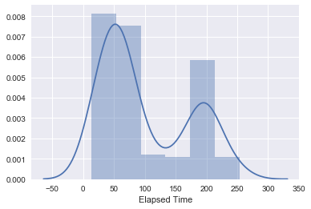

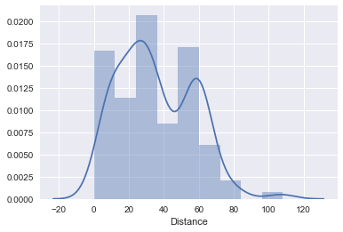

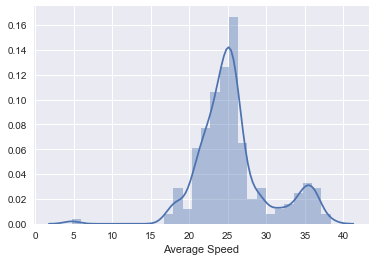

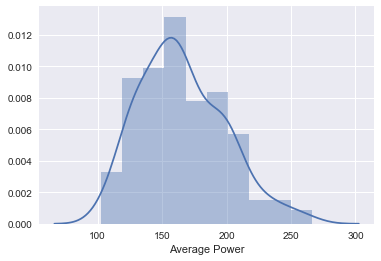

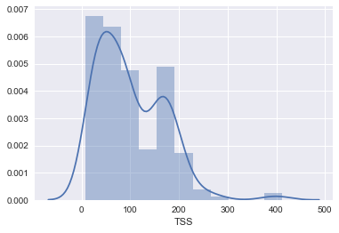

```python
# Removing rides with no power, these would be commutes or non-applicable
df = df[df['device_watts'] == True]

# Making separate data frames for key variables to judge distribution
dfElapsedTime = df[['elapsed_time']]
sns.distplot(dfElapsedTime).set(xlabel='Elapsed Time')

plt.figure()
dfDistance = df[['distance']]
sns.distplot(dfDistance).set(xlabel='Distance')

plt.figure()
dfDistance = df[['Average Speed']]
sns.distplot(dfDistance).set(xlabel='Average Speed')

plt.figure()
dfDistance = df[['Average Power']]
sns.distplot(dfDistance).set(xlabel='Average Power')

plt.figure()
dfDistance = df[['TSS']]
sns.distplot(dfDistance).set(xlabel='TSS')

plt.show()
```

### Distribution of variables

- **Time**: This graph shows a clear bimodal distribution with a slight right skew evident.
- **Distance**: With a large amount of data being centralised to two peaks, a biomodal distribution can be seen, there is also an evident rigth skew.
- **Average speed**: This graph is a similar shape to a normal distribution but due to a spike in the data at around 35 KM/hr, the graph is actually bimodal.
- **Average power**: This data is clearly right skewed, because of the large amount of data lies at the beginning of the graph.
- **TSS**: This data subset contains two significantly high peaks therefore it is a bimodal distribution and due to the outlying data at 400 it is right skewed.

# Relationships and correlations between key variables

The next step in this analysis is to explore the relationships between the following variables. Are any of them corrolated with each other (do they vary together in a predictable way)? Can we explain any relationships we observe?

- Distance
- Moving Time
- Average Speed
- Heart Rate
- Power (watts)
- Normalised power (NP)
- Training Stress Score
- Elevation Gain

```python
#Create a second dataframe for key variables
df2 = df[['distance','moving_time','Average Speed','average_heartrate', 'average_watts', 'NP', 'TSS', 'Elevation Gain']]
df2.corr()
```

|  | distance | moving_time | Average Speed | average_heartrate | average_watts | NP | TSS | Elevation Gain |
| --- | --- | --- | --- | --- | --- | --- | --- | --- |
| distance | 1.000000 | 0.972260 | 0.110461 | 0.078131 | 0.031858 | 0.202935 | 0.920085 | 0.804821 |
| moving_time | 0.972260 | 1.000000 | -0.100980 | -0.079929 | -0.112507 | 0.092046 | 0.909389 | 0.826645 |
| Average Speed | 0.110461 | -0.100980 | 1.000000 | 0.726858 | 0.720608 | 0.507974 | 0.037499 | -0.078419 |
| average_heartrate | 0.078131 | -0.079929 | 0.726858 | 1.000000 | 0.672457 | 0.578104 | 0.080077 | 0.047363 |
| average_watts | 0.031858 | -0.112507 | 0.720608 | 0.672457 | 1.000000 | 0.772574 | 0.150163 | -0.100030 |
| NP | 0.202935 | 0.092046 | 0.507974 | 0.578104 | 0.772574 | 1.000000 | 0.425102 | 0.228622 |
| TSS | 0.920085 | 0.909389 | 0.037499 | 0.080077 | 0.150163 | 0.425102 | 1.000000 | 0.830574 |
| Elevation Gain | 0.804821 | 0.826645 | -0.078419 | 0.047363 | -0.100030 | 0.228622 | 0.830574 | 1.000000 |

### Correlation between key variables (Correlation >0.80)

By examining the correlation matrix shown, some key correlations can be observed, which are:

- **Distance and Moving time**: This is an obvious correlation and is very predictable, as it is intuitive that as distance increases, so would moving time.
- **Distance and TSS**: This correlation is more interesting than the former, to a certain extent. The Training stress score (difficulty of the ride) has a strong linear correlation (indicating it is quite predictable), illustrating that as the ride becomes longer in length, so does the difficulty in it, which makes sense physiologically, as muscular fatigue sets in and the cardiovascular system is under intense strain.
- **Moving time and TSS**: The correlation between these two variables is quite predictable, since Distance and moving time are already correlated, it makes sense that moving time and TSS are correlated, as moving time increases, TSS should also increase, due to the physiological responses.
- **Distance and Elevation Gain**: Correlation in this instance is often dependent on the area ridden. This can be seen, for example, in the normal route which may involve hills and in turn a large amount of both ascent and descent. However if a different route is taken that is more flat and has only subtle changes in elevation there will be less correlation. The variables here show a high level of correlation therefore it can be assumed that the area ridden is precipitous.
- **Moving time and Elevation Gain**: Since distance and moving time are already strongly correlated in conjunction with distance and elevation gain being correlated, it only makes sense that moving time and elevation gain would be correlated, as when the ride progresses, hills or slopes would be encountered.
- **TSS and Elevation Gain**: The correlation between these two variables are of a slightly more interesting note, suggesting that as elevation gain increases, the training stress would also increase, as a result of the increasing angle of travel; suggesting that cycles were undertaken in mountainous areas.

# Exploration of the different work out types

The next stage in this analysis is going to be exploring the differences between the three categories: `Race`, `Workout` and `Ride`.

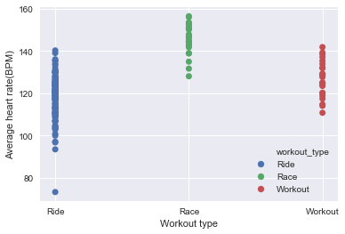

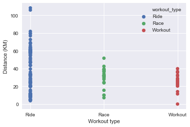

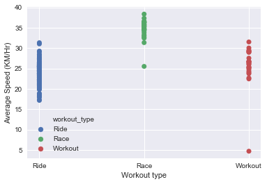

```python
#4
plt.tight_layout()

sns.scatterplot(x="workout_type", y="average_heartrate", data=df, hue = 'workout_type', linewidth = 0).set(
    ylabel='Average heart rate(BPM)',
    xlabel='Workout type')

plt.figure()
sns.scatterplot(x="workout_type", y="distance", data=df, hue = 'workout_type', linewidth = 0).set(
    ylabel='Distance (KM)',
    xlabel='Workout type')

plt.figure()
sns.scatterplot(x="workout_type", y="Average Speed", data=df, hue = 'workout_type', linewidth = 0).set(
    ylabel='Average Speed (KM/Hr)',
    xlabel='Workout type')

plt.show()
```

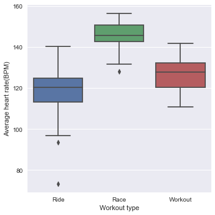

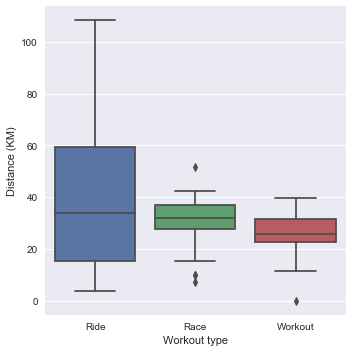

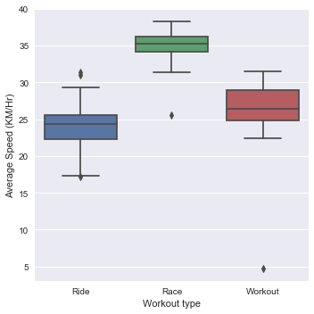

```python
sns.catplot(x="workout_type", y="average_heartrate", data=df, kind="box").set(
    ylabel='Average heart rate(BPM)',
    xlabel='Workout type')

sns.catplot(x="workout_type", y="Distance", data=df, kind="box").set(
    ylabel='Distance (KM)',
    xlabel='Workout type')

sns.catplot(x="workout_type", y="Average Speed", data=df, kind="box").set(
    ylabel='Average Speed (KM/Hr)',
    xlabel='Workout type')

plt.show()
```

### Relationships to note

# Variables and the relationship between kudos

```python
df3 = df[['distance','moving_time','Average Speed','average_heartrate', 'average_watts', 'NP', 'TSS', 'Elevation Gain', 'kudos']]
df3.corr()
```

|  | distance | moving_time | Average Speed | average_heartrate | average_watts | NP | TSS | Elevation Gain | kudos |
| --- | --- | --- | --- | --- | --- | --- | --- | --- | --- |
| distance | 1.000000 | 0.972260 | 0.110461 | 0.078131 | 0.031858 | 0.202935 | 0.920085 | 0.804821 | 0.752259 |
| moving_time | 0.972260 | 1.000000 | -0.100980 | -0.079929 | -0.112507 | 0.092046 | 0.909389 | 0.826645 | 0.665831 |
| Average Speed | 0.110461 | -0.100980 | 1.000000 | 0.726858 | 0.720608 | 0.507974 | 0.037499 | -0.078419 | 0.394387 |
| average_heartrate | 0.078131 | -0.079929 | 0.726858 | 1.000000 | 0.672457 | 0.578104 | 0.080077 | 0.047363 | 0.359824 |
| average_watts | 0.031858 | -0.112507 | 0.720608 | 0.672457 | 1.000000 | 0.772574 | 0.150163 | -0.100030 | 0.245937 |
| NP | 0.202935 | 0.092046 | 0.507974 | 0.578104 | 0.772574 | 1.000000 | 0.425102 | 0.228622 | 0.384543 |
| TSS | 0.920085 | 0.909389 | 0.037499 | 0.080077 | 0.150163 | 0.425102 | 1.000000 | 0.830574 | 0.694504 |
| Elevation Gain | 0.804821 | 0.826645 | -0.078419 | 0.047363 | -0.100030 | 0.228622 | 0.830574 | 1.000000 | 0.634021 |
| kudos | 0.752259 | 0.665831 | 0.394387 | 0.359824 | 0.245937 | 0.384543 | 0.694504 | 0.634021 | 1.000000 |

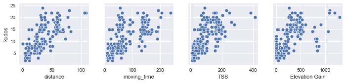

```python
sns.pairplot(data=df3,
                  y_vars=['kudos'],
                  x_vars=['distance', 'moving_time', 'TSS', 'Elevation Gain'])
```

By examining the correlation matrix with respect to kudos we can see what has the greatest effect when it increases. From our graphs we can determine that distance, moving time, TSS and elevation gain all have a strong impact on increasing kudos. Through further examinination of the scatterplot matrix, it becomes evident that there is a relationship between these four variables and the amount of kudos obtained from them, as shown by the decent linear relationship, as one of the x variables increases, kudos (y variable) is likely to increase as well.

# Overall summary of activity

Second to last, we want to generate an overall summary of activity by overlaying 3 key variables. These variables are Training Stress Score (TSS), Distance and Average Speed. We will explore the overall summary by looking at the monthly sum of TSS and the number of KM ridden. Finally, we will include the average speed for each month

```python
#Function to add legend
def addLegend():
    red= mpatches.Patch(color='r', label='TSS')
    green= mpatches.Patch(color='g', label='Average Speed ')
    blue= mpatches.Patch(color='b', label='Distance')
    plt.legend(handles=[red, green, blue])
```

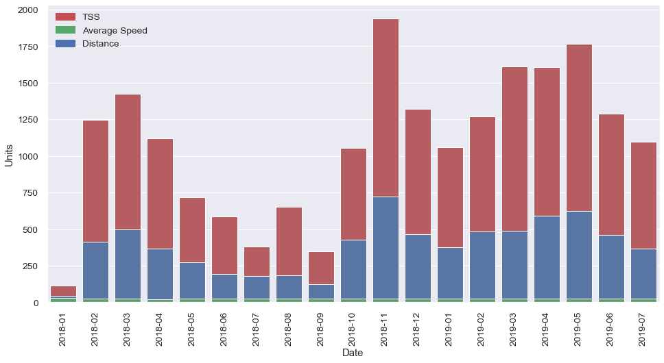

```python
df4 = df2.resample("M").sum()
df4['Time'] = df4.index

df5 = df2.resample("M").mean()
df5['Time'] = df4.index

plt.figure(figsize=(16, 8)), sns.set(font_scale = 1.25)
plt.xticks(rotation=90)

ax2 = sns.barplot(data=df4, x='Time', y = "TSS", color='r')
ax2 = sns.barplot(data=df4, x='Time', y = "distance", color='b')
ax2 = sns.barplot(data=df5, x='Time', y = "Average Speed", color='g').set(
    xticklabels=['2018-01', '2018-02','2018-03','2018-04',
                 '2018-05','2018-06','2018-07','2018-08',
                 '2018-09','2018-10','2018-11','2018-12',
                 '2019-01','2019-02','2019-03','2019-04',
                 '2019-05','2019-06','2019-07'])

plt.xlabel("Date"), plt.ylabel("Units")
addLegend()
plt.show()
```

We cannot easily make an overall judgement from the above graph, because it is evident that the data from other variables are overwhelmed by the data from TSS. TSS has a very large range compared to average speed which cannot have as large a range due to the nature and limits of road cycling. In this situation we can standardise the data to provide a superior and more interpretable graph.

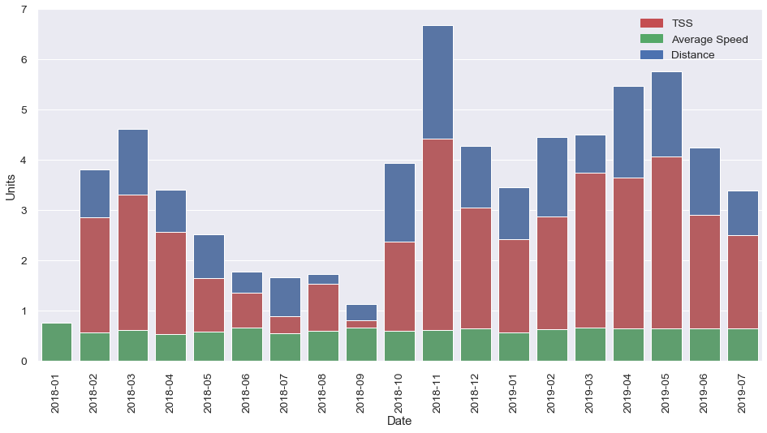

```python
df2_norm = (df2-df2.min())/(df2.max()-df2.min())

df4 = df2_norm.resample("M").sum()
df4['Time'] = df4.index

df5 = df2_norm.resample("M").mean()
df5['Time'] = df5.index

plt.figure(figsize=(16, 8)), sns.set(font_scale = 1.25)
plt.xticks(rotation=90)
ax2 = sns.barplot(data=df4, x='Time', y = "distance", color='b')
ax2 = sns.barplot(data=df4, x='Time', y = "TSS", color='r')
ax2 = sns.barplot(data=df5, x='Time', y = "Average Speed", color='g').set(
        xticklabels=['2018-01', '2018-02', '2018-03', '2018-04',
                     '2018-05', '2018-06', '2018-07', '2018-08',
                     '2018-09', '2018-10', '2018-11','2018-12',
                     '2019-01','2019-02','2019-03','2019-04',
                     '2019-05','2019-06','2019-07'])
plt.xlabel("Date"), plt.ylabel("Units")
addLegend()
plt.show()
```

This graph is more definitive when used to draw conclusions. Initially it appears there are a wide range of total values for each month, with some months reaching close to 5 units and a some months which do not reach 2 units. It does not appear as if there is a distinct pattern. One could suggest that there could be seasonal or work related commitments, causing this seemingly random distribution to occur. Similarly, the difficulty (which is TSS), as-well as the distance could be impacted as a direct result of changing life commitments.

The availability of races could also be a factor in the distribution of the graph, for example when there is a large race upcomming, the distance and TSS could increase in the prior months, then decrease when the race is nearer, allowing for recovery and preparation. Lastly, there could be a possibility of holidays or time off, as seen in November 2018, when all the metrics suddenly increase.

Average speed appears to remain constant over the entire period, confined to a small range of differences between each month. A detailed look at the data will reveal if there are any abnormailities.

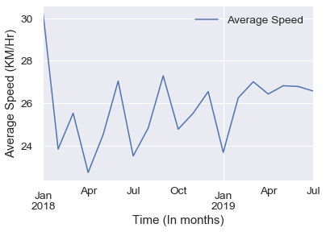

```python
## Remove warning label that would be shown, as the graph is. // get y axis to be in km/hr and add label
import warnings
warnings.simplefilter(action='ignore')

df6 = df2.resample("M").mean()
df6['Time'] = df4.index

df6.plot(x='Time', y='Average Speed')
plt.ylabel("Average Speed (KM/Hr)")
plt.xlabel("Time (In months)")
plt.show()
```

# *Portfolio 2*

```python
from sklearn.feature_selection import RFECV
from sklearn.svm import SVR
from sklearn.linear_model import LinearRegression
from sklearn.metrics import mean_squared_error
import datetime as dt
import matplotlib.dates as mdates
import numpy as np
import pandas as pd
import seaborn as sns
from matplotlib import pyplot as plt
from datetime import timedelta
plt.style.use('seaborn')
%matplotlib inline
from sklearn.model_selection import train_test_split
from sklearn import linear_model
from sklearn.metrics import r2_score
from sklearn.linear_model import LogisticRegression
from sklearn.metrics import confusion_matrix, accuracy_score
from sklearn.feature_selection import RFE
from sklearn.metrics import mean_squared_error
import warnings
warnings.filterwarnings("ignore")
```

# Reproduction and analysis of an energy use academic paper.

This notebook serves the purpose to reproduce and attempt to replicate some of the findings in the mentioned paper, ensuring that the paper is legitimate in nature. In addition to this, subjective exploration of the data will be conducted that was not included in the paper, as-well as using sklearn RFE to select the best features and compare the results in this notebook to the results in the paper. Sourced from:http://dx.doi.org/10.1016/j.enbuild.2017.01.083

## Loading Data

The data that is going to be used is the entire data set "energydata_complete.csv",

Variables:

- date time year-month-day, hour:minute:second
- Appliances, energy use in Wh
- lights, energy use of light fixtures in the house in Wh
- T1, Temperature in kitchen area, in Celsius
- RH_1, Humidity in kitchen area, in %
- T2, Temperature in living room area, in Celsius
- RH_2, Humidity in living room area, in %
- T3, Temperature in laundry room area
- RH_3, Humidity in laundry room area, in %
- T4, Temperature in office room, in Celsius
- RH_4, Humidity in office room, in %
- T5, Temperature in bathroom, in Celsius
- RH_5, Humidity in bathroom, in %
- T6, Temperature outside the building (north side), in Celsius
- RH_6, Humidity outside the building (north side), in %
- T7, Temperature in ironing room , in Celsius
- RH_7, Humidity in ironing room, in %
- T8, Temperature in teenager room 2, in Celsius
- RH_8, Humidity in teenager room 2, in %
- T9, Temperature in parents room, in Celsius
- RH_9, Humidity in parents room, in %
- To, Temperature outside (from Chièvres weather station), in Celsius
- Pressure (from Chièvres weather station), in mm Hg
- RH_out, Humidity outside (from Chièvres weather station), in %
- Windspeed (from Chièvres weather station), in m/s
- Visibility (from Chièvres weather station), in km
- Tdewpoint (from Chièvres weather station), °C
- rv1, Random variable 1, nondimensional
- rv2, Rnadom variable 2, nondimensional

```python
training = pd.read_csv("data/training.csv")
testing = pd.read_csv("data/testing.csv")
energy = pd.read_csv("data/energydata_complete.csv")

energy['date'] = pd.to_datetime(energy['date'])
energy.set_index('date', inplace=True)

training['date'] = pd.to_datetime(training['date'])
training.set_index('date', inplace=True)

testing['date'] = pd.to_datetime(testing['date'])
testing.set_index('date', inplace=True)
```

## Exploratory analysis of random variables

We will only conduct exploratory analysis on some initial variables to see what we can expect, as there are 28 variables in the data. They have been chosen randomly, as there are 28 variables in total.

```python
energy.head()
```

| date | Appliances | lights | T1 | RH_1 | T2 | RH_2 | T3 | RH_3 | T4 | RH_4 | ... | T9 | RH_9 | T_out | Press_mm_hg | RH_out | Windspeed | Visibility | Tdewpoint | rv1 | rv2 |
| --- | --- | --- | --- | --- | --- | --- | --- | --- | --- | --- | --- | --- | --- | --- | --- | --- | --- | --- | --- | --- | --- |
| 2016-01-11 17:00:00 | 60 | 30 | 19.89 | 47.596667 | 19.2 | 44.790000 | 19.79 | 44.730000 | 19.000000 | 45.566667 | ... | 17.033333 | 45.53 | 6.600000 | 733.5 | 92.0 | 7.000000 | 63.000000 | 5.3 | 13.275433 | 13.275433 |
| 2016-01-11 17:10:00 | 60 | 30 | 19.89 | 46.693333 | 19.2 | 44.722500 | 19.79 | 44.790000 | 19.000000 | 45.992500 | ... | 17.066667 | 45.56 | 6.483333 | 733.6 | 92.0 | 6.666667 | 59.166667 | 5.2 | 18.606195 | 18.606195 |
| 2016-01-11 17:20:00 | 50 | 30 | 19.89 | 46.300000 | 19.2 | 44.626667 | 19.79 | 44.933333 | 18.926667 | 45.890000 | ... | 17.000000 | 45.50 | 6.366667 | 733.7 | 92.0 | 6.333333 | 55.333333 | 5.1 | 28.642668 | 28.642668 |
| 2016-01-11 17:30:00 | 50 | 40 | 19.89 | 46.066667 | 19.2 | 44.590000 | 19.79 | 45.000000 | 18.890000 | 45.723333 | ... | 17.000000 | 45.40 | 6.250000 | 733.8 | 92.0 | 6.000000 | 51.500000 | 5.0 | 45.410389 | 45.410389 |
| 2016-01-11 17:40:00 | 60 | 40 | 19.89 | 46.333333 | 19.2 | 44.530000 | 19.79 | 45.000000 | 18.890000 | 45.530000 | ... | 17.000000 | 45.40 | 6.133333 | 733.9 | 92.0 | 5.666667 | 47.666667 | 4.9 | 10.084097 | 10.084097 |

5 rows × 28 columns

```python
energy.shape
```

```
(19735, 28)
```

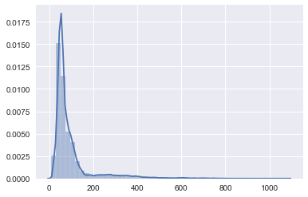

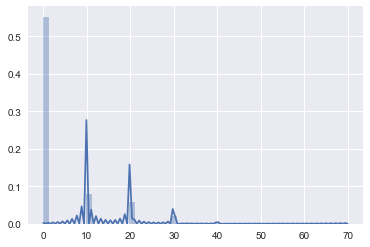

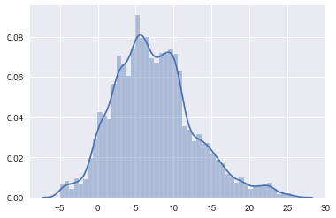

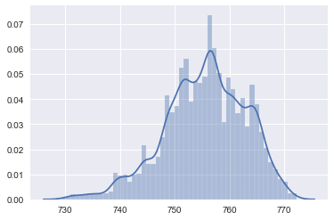

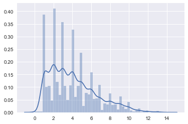

```python
sns.distplot(energy[['Appliances']])
plt.show()

sns.distplot(energy[['lights']])
plt.show()

sns.distplot(energy[['T_out']])
plt.show()

sns.distplot(energy[['Press_mm_hg']])
plt.show()

sns.distplot(energy[['Windspeed']])
plt.show()
```

```python
energy.head(20)
```

| date | Appliances | lights | T1 | RH_1 | T2 | RH_2 | T3 | RH_3 | T4 | RH_4 | ... | T9 | RH_9 | T_out | Press_mm_hg | RH_out | Windspeed | Visibility | Tdewpoint | rv1 | rv2 |
| --- | --- | --- | --- | --- | --- | --- | --- | --- | --- | --- | --- | --- | --- | --- | --- | --- | --- | --- | --- | --- | --- |
| 2016-01-11 17:00:00 | 60 | 30 | 19.890000 | 47.596667 | 19.200000 | 44.790000 | 19.790000 | 44.730000 | 19.000000 | 45.566667 | ... | 17.033333 | 45.530000 | 6.600000 | 733.500000 | 92.000000 | 7.000000 | 63.000000 | 5.300000 | 13.275433 | 13.275433 |
| 2016-01-11 17:10:00 | 60 | 30 | 19.890000 | 46.693333 | 19.200000 | 44.722500 | 19.790000 | 44.790000 | 19.000000 | 45.992500 | ... | 17.066667 | 45.560000 | 6.483333 | 733.600000 | 92.000000 | 6.666667 | 59.166667 | 5.200000 | 18.606195 | 18.606195 |
| 2016-01-11 17:20:00 | 50 | 30 | 19.890000 | 46.300000 | 19.200000 | 44.626667 | 19.790000 | 44.933333 | 18.926667 | 45.890000 | ... | 17.000000 | 45.500000 | 6.366667 | 733.700000 | 92.000000 | 6.333333 | 55.333333 | 5.100000 | 28.642668 | 28.642668 |
| 2016-01-11 17:30:00 | 50 | 40 | 19.890000 | 46.066667 | 19.200000 | 44.590000 | 19.790000 | 45.000000 | 18.890000 | 45.723333 | ... | 17.000000 | 45.400000 | 6.250000 | 733.800000 | 92.000000 | 6.000000 | 51.500000 | 5.000000 | 45.410389 | 45.410389 |
| 2016-01-11 17:40:00 | 60 | 40 | 19.890000 | 46.333333 | 19.200000 | 44.530000 | 19.790000 | 45.000000 | 18.890000 | 45.530000 | ... | 17.000000 | 45.400000 | 6.133333 | 733.900000 | 92.000000 | 5.666667 | 47.666667 | 4.900000 | 10.084097 | 10.084097 |
| 2016-01-11 17:50:00 | 50 | 40 | 19.890000 | 46.026667 | 19.200000 | 44.500000 | 19.790000 | 44.933333 | 18.890000 | 45.730000 | ... | 17.000000 | 45.290000 | 6.016667 | 734.000000 | 92.000000 | 5.333333 | 43.833333 | 4.800000 | 44.919484 | 44.919484 |
| 2016-01-11 18:00:00 | 60 | 50 | 19.890000 | 45.766667 | 19.200000 | 44.500000 | 19.790000 | 44.900000 | 18.890000 | 45.790000 | ... | 17.000000 | 45.290000 | 5.900000 | 734.100000 | 92.000000 | 5.000000 | 40.000000 | 4.700000 | 47.233763 | 47.233763 |
| 2016-01-11 18:10:00 | 60 | 50 | 19.856667 | 45.560000 | 19.200000 | 44.500000 | 19.730000 | 44.900000 | 18.890000 | 45.863333 | ... | 17.000000 | 45.290000 | 5.916667 | 734.166667 | 91.833333 | 5.166667 | 40.000000 | 4.683333 | 33.039890 | 33.039890 |
| 2016-01-11 18:20:00 | 60 | 40 | 19.790000 | 45.597500 | 19.200000 | 44.433333 | 19.730000 | 44.790000 | 18.890000 | 45.790000 | ... | 17.000000 | 45.290000 | 5.933333 | 734.233333 | 91.666667 | 5.333333 | 40.000000 | 4.666667 | 31.455702 | 31.455702 |
| 2016-01-11 18:30:00 | 70 | 40 | 19.856667 | 46.090000 | 19.230000 | 44.400000 | 19.790000 | 44.863333 | 18.890000 | 46.096667 | ... | 17.000000 | 45.290000 | 5.950000 | 734.300000 | 91.500000 | 5.500000 | 40.000000 | 4.650000 | 3.089314 | 3.089314 |
| 2016-01-11 18:40:00 | 230 | 70 | 19.926667 | 45.863333 | 19.356667 | 44.400000 | 19.790000 | 44.900000 | 18.890000 | 46.430000 | ... | 17.000000 | 45.290000 | 5.966667 | 734.366667 | 91.333333 | 5.666667 | 40.000000 | 4.633333 | 10.298729 | 10.298729 |
| 2016-01-11 18:50:00 | 580 | 60 | 20.066667 | 46.396667 | 19.426667 | 44.400000 | 19.790000 | 44.826667 | 19.000000 | 46.430000 | ... | 16.890000 | 45.290000 | 5.983333 | 734.433333 | 91.166667 | 5.833333 | 40.000000 | 4.616667 | 8.827838 | 8.827838 |
| 2016-01-11 19:00:00 | 430 | 50 | 20.133333 | 48.000000 | 19.566667 | 44.400000 | 19.890000 | 44.900000 | 19.000000 | 46.363333 | ... | 16.963333 | 45.290000 | 6.000000 | 734.500000 | 91.000000 | 6.000000 | 40.000000 | 4.600000 | 34.351142 | 34.351142 |
| 2016-01-11 19:10:00 | 250 | 40 | 20.260000 | 52.726667 | 19.730000 | 45.100000 | 19.890000 | 45.493333 | 19.000000 | 47.223333 | ... | 16.890000 | 45.326667 | 6.000000 | 734.616667 | 90.500000 | 6.000000 | 40.000000 | 4.516667 | 19.205186 | 19.205186 |
| 2016-01-11 19:20:00 | 100 | 10 | 20.426667 | 55.893333 | 19.856667 | 45.833333 | 20.033333 | 47.526667 | 19.000000 | 48.696667 | ... | 16.890000 | 45.345000 | 6.000000 | 734.733333 | 90.000000 | 6.000000 | 40.000000 | 4.433333 | 38.492071 | 38.492071 |
| 2016-01-11 19:30:00 | 100 | 10 | 20.566667 | 53.893333 | 20.033333 | 46.756667 | 20.100000 | 48.466667 | 19.000000 | 48.490000 | ... | 16.890000 | 45.326667 | 6.000000 | 734.850000 | 89.500000 | 6.000000 | 40.000000 | 4.350000 | 24.884962 | 24.884962 |
| 2016-01-11 19:40:00 | 90 | 10 | 20.730000 | 52.660000 | 20.166667 | 47.223333 | 20.200000 | 48.530000 | 18.926667 | 48.156667 | ... | 16.890000 | 45.290000 | 6.000000 | 734.966667 | 89.000000 | 6.000000 | 40.000000 | 4.266667 | 35.880925 | 35.880925 |
| 2016-01-11 19:50:00 | 70 | 30 | 20.856667 | 53.660000 | 20.200000 | 47.056667 | 20.200000 | 48.447500 | 18.890000 | 47.963333 | ... | 16.890000 | 45.290000 | 6.000000 | 735.083333 | 88.500000 | 6.000000 | 40.000000 | 4.183333 | 49.595305 | 49.595305 |
| 2016-01-11 20:00:00 | 80 | 30 | 20.890000 | 51.193333 | 20.200000 | 46.330000 | 20.200000 | 48.193333 | 18.963333 | 48.630000 | ... | 16.890000 | 45.200000 | 6.000000 | 735.200000 | 88.000000 | 6.000000 | 40.000000 | 4.100000 | 19.001759 | 19.001759 |
| 2016-01-11 20:10:00 | 140 | 40 | 20.890000 | 49.800000 | 20.200000 | 46.026667 | 20.166667 | 47.633333 | 19.033333 | 49.500000 | ... | 16.890000 | 45.200000 | 6.000000 | 735.233333 | 87.833333 | 6.000000 | 40.000000 | 4.066667 | 38.872261 | 38.872261 |

20 rows × 28 columns

We can see that from the exploratory analysis, that each variable has majorly different distributions. As-well, we can see that the data is relatively large with 19,735 observations. By quickly scrolling through the above cell, each data point is collected at a 10 minute interval.

## Reproduction and analysis

First set of plots shown, which are in the original paper as "Fig. 7. (A) Appliances energy consumption measurement for the whole period, (B) A closer look at the first week of data.".

I have simply just created two line plots and made some adjustments (axis labeling, colours, etc) and the result is essentially identical to the one in the paper.

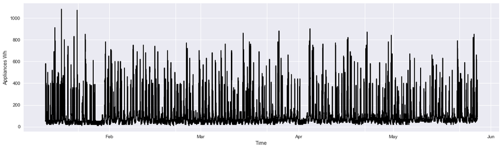

```python
plt.figure(figsize=(18,5))
sns.lineplot(data = energy, x = energy.index, y='Appliances', color = 'black').set(
    ylabel='Appliances Wh',
    xlabel='Time',
    xticklabels=['', 'Feb', '', 'Mar', '', 'Apr', '', 'May', '', 'Jun'])
plt.show()
```

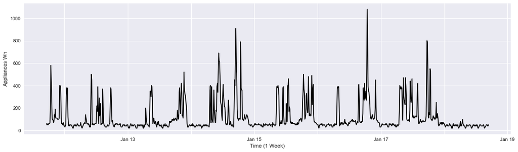

```python
plt.figure(figsize=(18,5))
sns.lineplot(data = energy, x = energy.index[1:1008], y=energy['Appliances'][1:1008], color = 'black').set(
    ylabel='Appliances Wh',
    xlabel='Time (1 Week)',
    xticklabels=['', 'Jan 13', '', 'Jan 15', '', 'Jan 17', '', 'Jan 19'])
plt.show()
```

The next two graphs are recreations of "Fig. 8. Appliances energy consumption distribution. Top: histogram, bottom: boxplot. The histogram shows the frequency of energy consumption in the interval (bar width), and the boxplot shows the location of the median with the black line." as shown in the paper

For the first graph, it is a histogram with Appliances Wh being plotted against the frequency. This plot replication is interesting, because in the R code, they used breaks = 40 (which I am assuming is synonymous with bins), however I had to use bins = 55 to replicate the plot.

The second graph however, is essentially identical to the one in the paper. It is simply a boxplot of the Appliances Wh showing the spread.

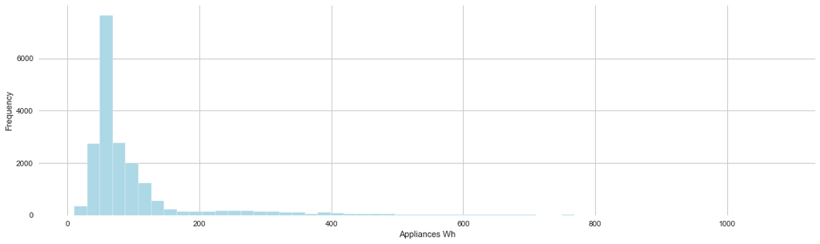

```python
sns.set_style("whitegrid")
plt.figure(figsize=(18,5))
hist = sns.distplot(energy['Appliances'], kde=False, rug=False, color='lightblue', hist_kws=dict(alpha=1), bins = 55)
hist.set(
    ylabel='Frequency',
    xlabel='Appliances Wh')
hist.set_yticks(np.linspace(0,6000,4))
plt.show()
```

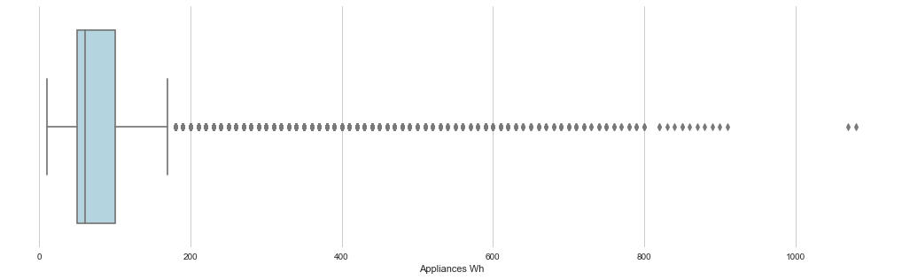

```python
plt.figure(figsize=(18,5))
box = sns.boxplot(energy['Appliances'], color='lightblue')
box.set(
    ylabel='',
    xlabel='Appliances Wh')
plt.show()
```

The below pairplot essentially matches Fig 9 in the paper, I however have not placed the variable named in the diagonal boxes as it is trival

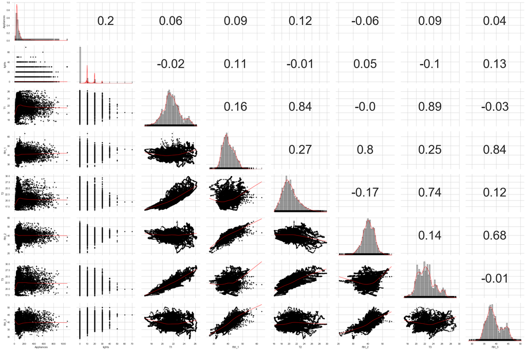

```python
#Help from: https://stackoverflow.com/questions/48139899/correlation-matrix-plot-with-coefficients-on-one-side-scatterplots-on-another/50690729#50690729
plt.figure(figsize=(18,5))
PairPlot = energy[['Appliances', 'lights','T1','RH_1','T2','RH_2','T3','RH_3']]

def corr(*args, **kwargs):
    corr_r = args[0].corr(args[1], 'pearson')
    corr_text = round(corr_r, 2)
    ax = plt.gca()
    ax.annotate(corr_text, [.5, .5,],  xycoords="axes fraction",
                ha='center', va='center', fontsize= 50)

g = sns.PairGrid(PairPlot, aspect=1.5, diag_sharey=False, despine=False)

g.map_lower(sns.regplot, lowess=True, ci=False,
            line_kws={'color': 'red', 'lw': 1},
            scatter_kws={'color': 'black', 's': 20})

g.map_diag(sns.distplot, color='black',
           kde_kws={'color': 'red', 'cut': 0.7, 'lw': 1},
           hist_kws={'histtype': 'bar', 'lw': 2,
                     'edgecolor': 'k', 'facecolor':'grey'})

g.map_diag(sns.rugplot, color='black')
g.map_upper(corr)
```

# Linear regression and basic RFE

Converting week status and days of week of training and testing data frames into dummy variables

```python
training_weeksbinary = pd.get_dummies(training['WeekStatus'])
training_daysbinary = pd.get_dummies(training['Day_of_week'])
training_binary = training_weeksbinary.join(training_daysbinary)

testing_weeksbinary = pd.get_dummies(testing['WeekStatus'])
testing_daysbinary = pd.get_dummies(testing['Day_of_week'])
testing_binary = testing_weeksbinary.join(testing_daysbinary)

new_train_data = training.join(training_binary)
new_test_data = testing.join(testing_binary)
```

```python
new_train_data.drop(['Appliances', 'WeekStatus', 'Day_of_week'], axis=1).shape
```

```
(14803, 37)
```

matches shape shown in line 499 in the paper code

```python
new_test_data.drop(['Appliances', 'WeekStatus', 'Day_of_week'], axis=1).shape
```

```
(4932, 37)
```

matches shape shown in line 504 in the paper code

```python
X_train = new_train_data.drop(['Appliances', 'WeekStatus', 'Day_of_week'], axis=1)
Y_train = new_train_data['Appliances']

X_test = new_test_data.drop(['Appliances', 'WeekStatus', 'Day_of_week'], axis=1)
Y_test = new_test_data['Appliances']

model = LinearRegression()
model.fit(X_train, Y_train)
predicted = model.predict(X_test)

print("MSE:", mean_squared_error(Y_test, predicted))
print("RMSE:", np.sqrt(mean_squared_error(Y_test, predicted)))
print("R^2:", r2_score(Y_test, predicted))
```

```
MSE: 8681.847902503363
RMSE: 93.17643426587735
R^2: 0.15900712778675563
```

The linear model I have created is essentially, if not completely identical to the results found in the paper. The RSME and R squared values in the paper are 93.18 and 0.16 respectively.

```python
feature_cols = new_train_data.drop(['Appliances', 'WeekStatus', 'Day_of_week'], axis=1).columns
estimator = LinearRegression()
selector = RFE(estimator)
selector = selector.fit(X_train, Y_train)

supp = selector.get_support()
print("Selected features:", feature_cols[supp])
print("Coeffs:", selector.estimator_.coef_)

# test the model
predicted = selector.predict(X_test)
print("MSE:", mean_squared_error(Y_test, predicted))
print("RMSE:", np.sqrt(mean_squared_error(Y_test, predicted)))
print("R^2:", r2_score(Y_test, predicted))
```

```
Selected features: Index(['RH_1', 'T2', 'RH_2', 'T3', 'RH_3', 'T6', 'T8', 'RH_8', 'T9', 'T_out',
       'Weekday', 'Friday', 'Monday', 'Saturday', 'Sunday', 'Thursday',
       'Tuesday', 'Wednesday'],
      dtype='object')
Coeffs: [ 16.92371855 -18.15383266 -14.1707256   24.12465729   5.92793575
   6.04242307  11.68305444  -6.77673394 -22.69565325  -5.299162
  -4.25587334   9.11185527   7.88862704   9.51475174  -5.25887841
  -7.44215349  -9.30762011  -4.50658205]
MSE: 8967.866327018066
RMSE: 94.69881903708233
R^2: 0.13130110724369037
```

The most basic form of RFE provides subpar results, both the RSME and R squared values are negatively effected. RSME has increased and R squared value has decreased, this could be a result of possibly overfitting the variables, leading to decreased performance. Similarly, the top variables chosen do not match the variable ranking in the paper, however in the final cells, it is much different. Below is the RSME plotted against variables chosen with the standard RFE, I am not sure how to replicate the plot with RFECV + RandomForestRegressor.

```python
feature_cols = new_train_data.drop(['Appliances', 'WeekStatus', 'Day_of_week'], axis=1).columns
Variables = list(range(1,36))
RSME_scores = []
for i in Variables:
    estimator = LinearRegression()
    selector = RFE(estimator, i)
    selector = selector.fit(X_train, Y_train)
    supp = selector.get_support()
    predicted = selector.predict(X_test)
    RSME_scores.append(np.sqrt(mean_squared_error(Y_test, predicted)))
```

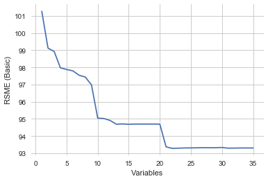

```python
RSMEPlot = sns.lineplot(x=Variables, y=RSME_scores)
RSMEPlot.set(xlabel='Variables', ylabel='RSME (Basic)')
plt.show()
```

The following is figure 13 in the paper, Residuals and appliances’ energy consumption plot of the lm model. Matches the figure well.

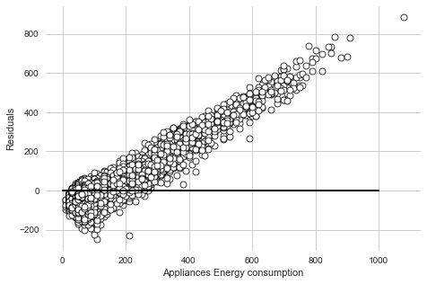

```python
plt.figure(figsize=(7.5,5)) # Figsize of 7.5, 5 essentially matches dimensions of one in paper
yHat = model.predict(X_train)
residuals = new_train_data['Appliances'] - yHat
sns.scatterplot(new_train_data['Appliances'], residuals, color='white', edgecolor='black', alpha=1)
plt.ylabel('Residuals')
plt.xlabel('Appliances Energy consumption')
plt.plot([1000, 0], [0, 0], linewidth=2, color= 'black')
plt.show()
```

# RFE with cross-validation and RandomForestRegressor

The first cell contains 100 n_estimators for RFECV & RandomForestRegressor, it took 30 minutes to run on a powerful machine. If you want to run the second cell with n_estimators = 500, it will take a significantly long time and it would be wise to undertake this on a well equipped computer.

The results of the first cell are impressive, considering RSME has dropped by >20, and the R squared value is much better in regards to the linear model. With n_estimators = 500, I would say that similar, if not identical results to the paper would be obtained. With n_estimators = 100, the results of my RFECV with RandomForestRegressor are a R squared value of 0.52 (0.02 less than the papers' result) and a RSME of 70.60 (2.12 more than the paper's result). Finally, all of the selected variables in order of importance match those in the paper up to windspeed. With n_estimators = 500, I can confidently assert that identical results will be obtained.

```python
from sklearn.ensemble import RandomForestRegressor
feature_cols = new_train_data.drop(['Appliances', 'WeekStatus', 'Day_of_week'], axis=1).columns
X_train2 = new_train_data.drop(['Appliances', 'WeekStatus', 'Day_of_week'], axis=1)
Y_train2 = new_train_data['Appliances']
estimator = RandomForestRegressor(n_estimators=100, random_state=1, n_jobs= -1)
selector = RFECV(estimator, cv = 10)
selector = selector.fit(X_train2, Y_train2)

supp = selector.get_support()
print("Selected features:", feature_cols[supp])
#print("Coeffs:", selector.estimator_.coef_)


# test the model
predicted = selector.predict(X_test)
print("MSE:", mean_squared_error(Y_test, predicted))
print("RMSE:", np.sqrt(mean_squared_error(Y_test, predicted)))
print("R^2:", r2_score(Y_test, predicted))
```

```
Selected features: Index(['lights', 'T1', 'RH_1', 'T2', 'RH_2', 'T3', 'RH_3', 'T4', 'RH_4', 'T5',
       'RH_5', 'T6', 'RH_6', 'T7', 'RH_7', 'T8', 'RH_8', 'T9', 'RH_9', 'T_out',
       'Press_mm_hg', 'RH_out', 'Windspeed', 'Visibility', 'Tdewpoint', 'rv1',
       'rv2', 'NSM', 'Friday', 'Monday', 'Saturday'],
      dtype='object')
MSE: 4983.107725060827
RMSE: 70.59113064019323
R^2: 0.5172965334904648
```

```python
from sklearn.ensemble import RandomForestRegressor
feature_cols = new_train_data.drop(['Appliances', 'WeekStatus', 'Day_of_week'], axis=1).columns
X_train2 = new_train_data.drop(['Appliances', 'WeekStatus', 'Day_of_week'], axis=1)
Y_train2 = new_train_data['Appliances']
estimator = RandomForestRegressor(n_estimators=500, random_state=1, n_jobs= -1)
selector = RFECV(estimator, cv = 10)
selector = selector.fit(X_train2, Y_train2)

supp = selector.get_support()
print("Selected features:", feature_cols[supp])
#print("Coeffs:", selector.estimator_.coef_)


# test the model
predicted = selector.predict(X_test)
print("MSE:", mean_squared_error(Y_test, predicted))
print("RMSE:", np.sqrt(mean_squared_error(Y_test, predicted)))
print("R^2:", r2_score(Y_test, predicted))
```

# Portfolio 3 - Clustering Visualisation

K-means clustering is one of the simplest and popular unsupervised learning algorithms. Typically, unsupervised algorithms make inferences from datasets using only input vectors without referring to known, or labelled, outcomes. This notebook illustrates the process of K-means clustering by generating some random clusters of data and then showing the iterations of the algorithm as random cluster means are updated.

We first generate random data around 4 centers.

```python
import numpy as np
import pandas as pd
from copy import deepcopy
from matplotlib import pyplot as plt
%matplotlib inline
```

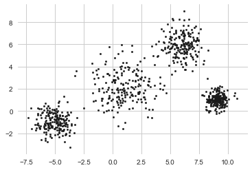

```python
center_1 = np.array([1,2])
center_2 = np.array([6,6])
center_3 = np.array([9,1])
center_4 = np.array([-5,-1])

# Generate random data and center it to the four centers each with a different variance
np.random.seed(5)
data_1 = np.random.randn(200,2) * 1.5 + center_1
data_2 = np.random.randn(200,2) * 1 + center_2
data_3 = np.random.randn(200,2) * 0.5 + center_3
data_4 = np.random.randn(200,2) * 0.8 + center_4

data = np.concatenate((data_1, data_2, data_3, data_4), axis = 0)

plt.scatter(data[:,0], data[:,1], s=7, c='k')
plt.show()
```

## 1. Generate random cluster centres

You need to generate four random centres.

This part of portfolio should contain at least:

- The number of clusters `k` is set to 4;
- Generate random centres via `centres = np.random.randn(k,c)*std + mean` where `std` and `mean` are the standard deviation and mean of the data. `c` represents the number of features in the data. Set the random seed to 6.
- Color the generated centers with `green`, `blue`, `yellow`, and `cyan`. Set the edgecolors to `red`.

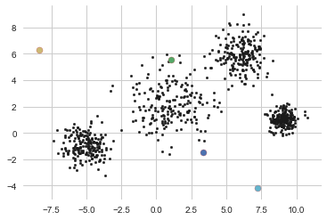

```python
np.random.seed(6)
centres = np.random.randn(4,2)*data.std() + data.mean()
plt.scatter(data[:,0], data[:,1], s=7, c='k')

bank = 'g', 'b', 'y', 'c'
for i in range(0, 4):
        plt.scatter(centres[i][0], centres[i][1], color = bank[i], s = 50).set_edgecolor('r')
plt.show()
```

## 2. Visualise the clustering results in each iteration

The KMeans clustering algorithim is as follows:

[figure not shown]

```python
# Euclidean Distance Caculator (Sourced from: https://stackoverflow.com/questions/1401712/how-can-the-euclidean-distance-be-calculated-with-numpy, with some minor adjustments (axis introduction for cluster centres))
def dist(a, b, ax=1):
    return np.linalg.norm(a - b, axis=ax)
```

Initially create some variables in order to assist us in the stages of Kmeans clustering, the purpose of the variables are as follows

- **CentroidNew**: Provide a place to store new values of centroids once computed
- **clusters**: Provide a label for each data point, to which cluster it belongs to. Currently, every data point does not belong to a cluster, it is just a copy of the data matrix, with 0 values to be filled in later to the correct cluster.
- **Var**: Will provide the Euclidean distance between new and old centroids, which serves as the stopping criteria.

```python
CentroidNew = np.zeros(centres.shape)

clusters = np.zeros(len(data))

Var = dist(centres, CentroidNew, None)
```

## 2. Cluster membership

This function will be useful in the following steps to compute the final result, the function is the second stage of K-Means clustering, where we decide the cluster memberships of the data samples by assigning them to the nearest-cluster centroids.

The function works by recieving an input data set, it then computes the distance between each data point and the initially randomly selected cluster centroids. Since there are 4 clusters, each data point distance will be contained within a array of length 4. Finally, each data point is chosen to be in a cluster, by selecting the the minimum array value index. This process is repeated until each data point is in a cluster. An example is shown below.

```python
def ClosetCluster(dataset):
    for i in range(len(dataset)):
        clusters[i] = np.argmin(dist(dataset[i], centres))
```

```python
print(dist(data[1], centres))
print(np.argmin(dist(data[1], centres)))
```

```
[ 5.32200547  3.38203573 13.82586139  6.33558191]
1
```

## 3. Updating cluster centres

The next function is the third step of the algorithm, in which we re-estimate the 4 cluster centers by assuming the memberships found above are correct. The new cluster centroids are then found by taking the average of all the points assigned to the specific cluster.

The function works by recieving an input data set, then looping through each cluster, shown by the first loop. The clusterpoints variable simply creates an array and just assigns each data point to the cluster they belong to. This function then calculates the centres new position based upon this data.

```python
def ReEstimate (dataset):
    for i in range(0, 4):
        clusterpoints = [dataset[x]
                  for x in range(len(dataset))
                  if clusters[x] == i]
        centres[i] = np.mean(clusterpoints, axis=0)
```

## 4. Loop until there is no change

Now we must combine these functions to do step 4, in order to get the final resulting clusters, this is done via the following cells in which the entire algorithm is run. It takes the previous functions and uses them in order to compute the final result. The cell will loop until the error is = 0 (No distance between old and new centroids). A secondary function has been created to show the process of each iteration.

```python
def plot():
    plt.subplots()
    for i in range(0, 4):
        clusterpoints = np.array([data[x]
                                  for x in range(len(data))
                                  if clusters[x] == i])
        plt.scatter(clusterpoints[:, 0], clusterpoints[:, 1], s=7, color=bank[i])
        plt.scatter(centres[i][0], centres[i][1], color = bank[i], s = 200).set_edgecolor('r')
```

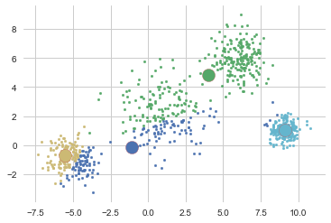

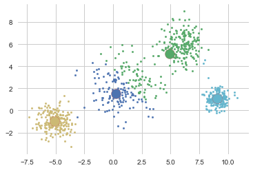

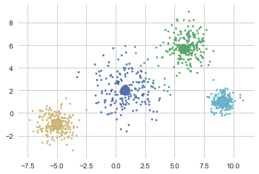

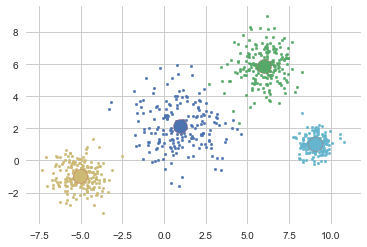

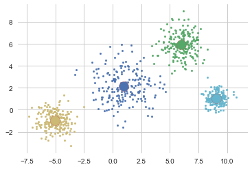

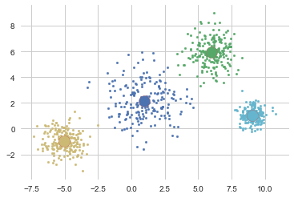

```python
while Var !=0:
    #Get closet clusters
    ClosetCluster(data)
    #Store new centroid values
    CentroidNew = deepcopy(centres)
    #Update cluster centres
    ReEstimate(data)
    #Check for whether the centre has moved
    Var = dist(centres, CentroidNew, None)
    plot()
```